# Drug risk prediction in Chicago

Anran Zheng

2021/10/27

## Introduction

Data science has been an ideal planning tool, which makes sure that the limited resources (e.g. police) matches the demand for resources (e.g. crime). For many years, policies have been planning based on the crime data for a better risk prediction. Under this premise, this study created a geospatial risk-predicted model to predict the drug crimes in Chicago. First, drug crime data with its relevant risk factors were wrangled into geospatial features. Their correlations were analyzed and based on that, estimating models were built to predict the drug crime in Chicago. Finally, model validation is conducted by comparing the predictions with the traditions.

## Creating the fishnet

This study focused on the drug crime data as selection bias in Chicago in year 2017, which is gathered from Chicago Open Data site. Its distribution as well as crime cluster is shown in Figure 1. There are some hotspots on the west and middle-south site of Chicago, which suggesting selection bias.  
Such selection bias might be an issue in both the prospective of police and offenders. In terms of police, police are relative harder to convict offenders with drug, since they may need to search the whole body or the entire home of offenders. However, offenders with drug tend not to expose their drugs to the police. Most drug offenders try to hide their drugs in privacy trading channels. On the other hand, victims might not know how to report the incidence, since taking drug is not always the immediate cause that will pose threaten on others. For example, if a drug addicted came to steal, this type of crime is still directly related to robbery since it is hard to detect that the offender is taking drug, even he behave some common physical and mental symptoms of a drug taker. To report the drug incidents, victims may just phone police to complain. However, their calls are always challenging for police to handle and interpret. Furthermore, sometimes victims behave more aggressive than the drug takers. For example, they may threaten drug users and sellers in extreme ways, which are also likely leading to the criminal (Moore & Kleiman, 1989). The bias in drug crime is closely related to regional economic levels and race context, which will be further discussed in the later analysis.

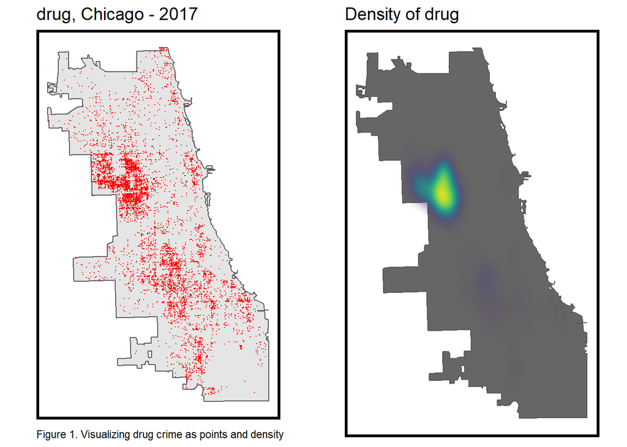

```r
policeDistricts <-
  st_read("https://data.cityofchicago.org/api/geospatial/fthy-xz3r?method=export&format=GeoJSON") %>%
  st_transform('ESRI:102271') %>%
  dplyr::select(District = dist_num)

policeBeats <-
  st_read("https://data.cityofchicago.org/api/geospatial/aerh-rz74?method=export&format=GeoJSON") %>%
  st_transform('ESRI:102271') %>%
  dplyr::select(District = beat_num)

bothPoliceUnits <- rbind(mutate(policeDistricts, Legend = "Police Districts"),
                         mutate(policeBeats, Legend = "Police Beats"))

drug <-
  read.socrata("https://data.cityofchicago.org/Public-Safety/Crimes-2017/d62x-nvdr") %>%
  filter(Primary.Type == "NARCOTICS") %>%
  mutate(x = gsub("[()]", "", Location)) %>%
  separate(x,into= c("Y","X"), sep=",") %>%
  mutate(X = as.numeric(X),Y = as.numeric(Y)) %>%
  #na.omit() %>%
  filter(is.na(X)==FALSE) %>%
  st_as_sf(coords = c("X", "Y"), crs = 4326, agr = "constant")%>%
  st_transform('ESRI:102271') %>%
  distinct()

chicagoBoundary <-
  st_read(file.path(root.dir,"/Chapter5/chicagoBoundary.geojson")) %>%
  st_transform('ESRI:102271')

drug<-st_intersection(drug,chicagoBoundary)

grid.arrange(ncol=2,
             ggplot() +
               geom_sf(data = chicagoBoundary) +
               geom_sf(data = drug, colour="red", size=0.1, show.legend = "point") +
               labs(title= "drug, Chicago - 2017",caption="Figure 1. Visualizing drug crime as points and density") +
               mapTheme(title_size = 14),

             ggplot() +
               geom_sf(data = chicagoBoundary, fill = "grey40") +
               stat_density2d(data = data.frame(st_coordinates(drug)),
                              aes(X, Y, fill = ..level.., alpha = ..level..),
                              size = 0.01, bins = 40, geom = 'polygon') +
               scale_fill_viridis() +
               scale_alpha(range = c(0.00, 0.35), guide = FALSE) +
               labs(title = "Density of drug") +
               mapTheme(title_size = 14) + theme(legend.position = "none"))
```

## Data wrangling: Joining burglaries to the fishnet

In order to avoid the regional bias, a fishnet was created with 500ft by 500ft grid cell. Figure 2 maps the count of drug crimes by each cell, where the yellow area highlights the high amount of drug crimes detected by the police. This was consistent with figure 1, which also shows the crime hotspots in the west and middle-south Chicago.

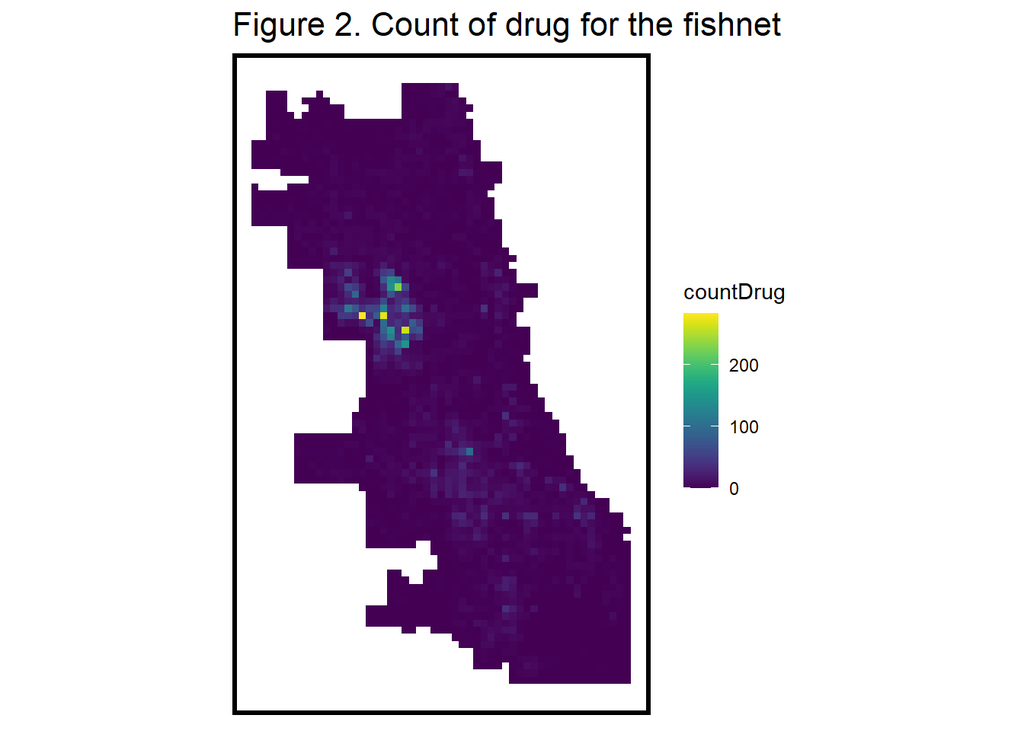

```r
fishnet <-
  st_make_grid(chicagoBoundary,
               cellsize = 500,
               square = TRUE) %>%
  .[chicagoBoundary] %>%            # <- MDH Added
  st_sf() %>%
  mutate(uniqueID = rownames(.))

## add a value of 1 to each crime, sum them with aggregate
crime_net <-
  dplyr::select(drug) %>%
  mutate(countDrug = 1) %>%
  aggregate(., fishnet, sum) %>%
  mutate(countDrug = replace_na(countDrug, 0),
         uniqueID = rownames(.),
         cvID = sample(round(nrow(fishnet) / 24),
                       size=nrow(fishnet), replace = TRUE))

ggplot() +
  geom_sf(data = crime_net, aes(fill = countDrug), color = NA) +
  scale_fill_viridis() +
  labs(title = "Figure 2. Count of drug for the fishnet") +
  mapTheme()
```

## Wrangling risk factors

A small set of risk factors were chosen to predict where drug crimes happen, including:  
- abandoned cars  
- abandoned buildings  
- graffiti  
- streetLightsOut  
- sanitation  
- liquorRetail  
- Garbage Carts  
- public schools  
- Rodent Baiting  
Based on the latter three risk factors, we hypothesized that:  
(1) places close to garbage cars mean lower sanitation condition, which may attract the attention of police and thus more drug crimes can be detected;  
(2) places next to the public schools suggest higher educational condition and clustering or children, where polices patroled frequently, then drug crime can be easily detected;  
(3) places close to rodent baiting mean poorer environment, where polices also patroled frequently and easily find more drug crimes.

```r
#multiple map of your risk factors in the fishnet (counts, distance, and/or other feature engineering approaches).
abandonCars <-
  read.socrata(paste0("https://data.cityofchicago.org/Service",
                      "-Requests/311-Service-Requests-Abandoned-Vehicles/",
                      "3c9v-pnva")) %>%
  mutate(year = substr(creation_date,1,4)) %>%
  filter(year == "2017") %>%
  dplyr::select(Y = latitude, X = longitude) %>%
  na.omit() %>%
  st_as_sf(coords = c("X","Y"), crs=4326, agr="constant") %>%
  st_transform(st_crs(fishnet)) %>%
  mutate(Legend = "Abandoned_Cars")

abandonBuildings <-
  read.socrata(paste0("https://data.cityofchicago.org/Service",
                      "-Requests/311-Service-Requests-Vacant-and-Abandoned-Building/",
                      "7nii-7srd")) %>%
  mutate(year=substr(date_service_request_was_received,1,4))%>%
  filter(year == "2017") %>%
  dplyr::select(Y = latitude, X = longitude) %>%
  na.omit() %>%
  st_as_sf(coords = c("X","Y"), crs=4326, agr="constant") %>%
  st_transform(st_crs(fishnet)) %>%
  mutate(Legend = "Abandoned_Buildings")

graffiti <-
  read.socrata(paste0("https://data.cityofchicago.org/Service",
                      "-Requests/311-Service-Requests-Graffiti-Removal-Historical/",
                      "hec5-y4x5")) %>%
  mutate(year = substr(creation_date,1,4)) %>%
  filter(year == "2017") %>%
  filter(where_is_the_graffiti_located_ %in%
           c("Front","Rear","Side")) %>%
  dplyr::select(Y = latitude, X = longitude) %>%
  na.omit() %>%
  st_as_sf(coords = c("X","Y"), crs=4326, agr="constant") %>%
  st_transform(st_crs(fishnet)) %>%
  mutate(Legend = "Graffiti")

streetLightsOut <-
  read.socrata(paste0("https://data.cityofchicago.org/Service",
                      "-Requests/311-Service-Requests-Street-Lights-All-Out/",
                      "zuxi-7xem")) %>%
  mutate(year = substr(creation_date,1,4)) %>%
  filter(year == "2017") %>%
  dplyr::select(Y = latitude, X = longitude) %>%
  na.omit() %>%
  st_as_sf(coords = c("X","Y"), crs=4326, agr="constant") %>%
  st_transform(st_crs(fishnet)) %>%
  mutate(Legend = "Street_Lights_Out")

sanitation <-
  read.socrata(paste0("https://data.cityofchicago.org/Service",
                      "-Requests/311-Service-Requests-Sanitation-Code-Complaints-Hi/",
                      "me59-5fac")) %>%
  mutate(year = substr(creation_date,1,4)) %>%
  filter(year == "2017") %>%
  dplyr::select(Y = latitude, X = longitude) %>%
  na.omit() %>%
  st_as_sf(coords = c("X","Y"), crs=4326, agr="constant") %>%
  st_transform(st_crs(fishnet)) %>%
  mutate(Legend = "Sanitation")

liquorRetail <-
  read.socrata(paste0("https://data.cityofchicago.org/resource/",
                      "nrmj-3kcf.json")) %>%
  filter(business_activity ==
           "Retail Sales of Packaged Liquor") %>%
  dplyr::select(Y = latitude, X = longitude) %>%
  na.omit() %>%
  st_as_sf(coords = c("X","Y"), crs=4326, agr="constant") %>%
  st_transform(st_crs(fishnet)) %>%
  mutate(Legend = "Liquor_Retail")

neighborhoods <-
  st_read(paste0("https://raw.githubusercontent.com/",
                 "blackmad/neighborhoods/master/chicago.geojson")) %>%
  st_transform(st_crs(fishnet))

#Garbage Carts
GarbageCarts<-read.socrata("https://data.cityofchicago.org/Service-Requests/311-Service-Requests-Garbage-Carts-Historical/9ksk-na4q") %>%
  mutate(year = substr(creation_date,1,4)) %>%
  filter(year == "2017") %>%
  dplyr::select(Y = latitude, X = longitude) %>%
  na.omit() %>%
  st_as_sf(coords = c("X", "Y"), crs = 4326, agr = "constant") %>%
  st_transform(st_crs(fishnet)) %>%
  mutate(Legend = "Garbage_Carts")

#public schools
schools <-
  read.socrata("https://data.cityofchicago.org/resource/d2h8-2upd.json")%>%
  dplyr::select(Y = lat, X = long) %>%
  na.omit() %>%
  st_as_sf(coords = c("X", "Y"), crs = 4326, agr = "constant") %>%
  st_transform(st_crs(fishnet)) %>%
  mutate(Legend = "public_schools")

#Rodent Baiting
RodentBaiting <-
  read.socrata("https://data.cityofchicago.org/Service-Requests/311-Service-Requests-Rodent-Baiting-Historical/97t6-zrhs") %>%
  mutate(year = substr(creation_date,1,4)) %>%
  filter(year == "2017") %>%
  dplyr::select(Y = latitude, X = longitude) %>%
  na.omit() %>%
  st_as_sf(coords = c("X", "Y"), crs = 4326, agr = "constant") %>%
  st_transform(st_crs(fishnet)) %>%
  mutate(Legend = "Rodent_Baiting")
```

## Feature engineering - Count of risk factors by grid cell

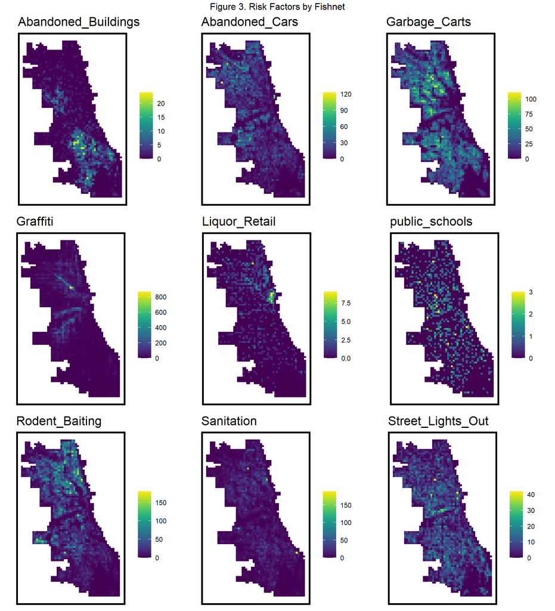

```r
vars_net <-
  rbind(abandonCars,streetLightsOut,abandonBuildings,
        liquorRetail, graffiti, sanitation, schools,GarbageCarts,RodentBaiting)%>%
  st_join(., fishnet, join=st_within) %>%
  st_drop_geometry() %>%
  group_by(uniqueID, Legend) %>%
  summarize(count = n()) %>%
  full_join(fishnet, by = "uniqueID") %>%
  spread(Legend, count, fill=0) %>%
  st_sf() %>%
  dplyr::select(-`<NA>`) %>%
  na.omit() %>%
  ungroup()

vars_net.long<-gather(vars_net,Variable,value,-geometry,-uniqueID)
vars<-unique(vars_net.long$Variable)
mapList<-list()
for(i in vars)
  {mapList[[i]]<-
    ggplot()+
    geom_sf(data=filter(vars_net.long,Variable==i),
            aes(fill=value),colour=NA)+
    scale_fill_viridis(name="")+
    labs(title=i)+
    mapTheme()}

do.call(grid.arrange,c(mapList,ncol=3,top="Figure 3. Risk Factors by Fishnet"))
```

## Feature engineering - Nearest Neighbor Feature

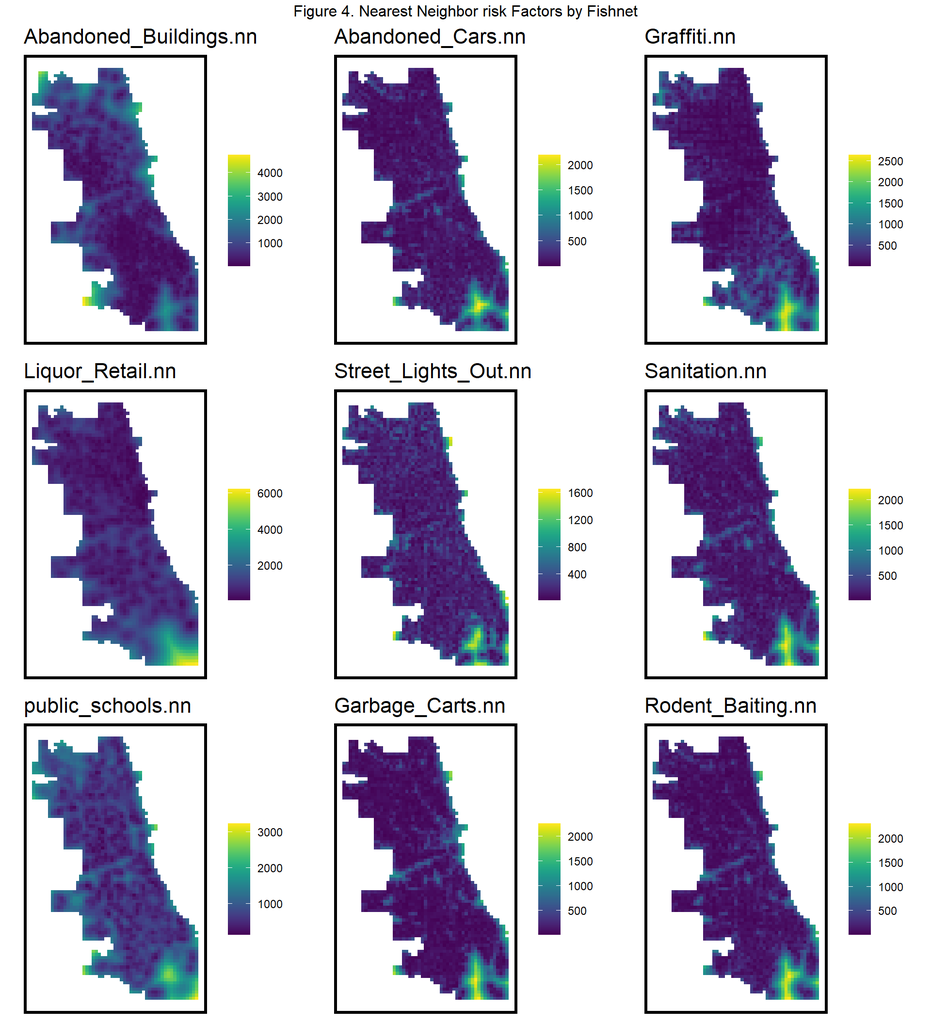

```r
nn_function <- function(measureFrom,measureTo,k) {
  measureFrom_Matrix <-
    as.matrix(measureFrom)
  measureTo_Matrix <-
    as.matrix(measureTo)
  nn <-
    get.knnx(measureTo, measureFrom, k)$nn.dist
  output <-
    as.data.frame(nn) %>%
    rownames_to_column(var = "thisPoint") %>%
    gather(points, point_distance, V1:ncol(.)) %>%
    arrange(as.numeric(thisPoint)) %>%
    group_by(thisPoint) %>%
    summarize(pointDistance = mean(point_distance)) %>%
    arrange(as.numeric(thisPoint)) %>%
    dplyr::select(-thisPoint) %>%
    pull()

  return(output)
}

st_c    <- st_coordinates
st_coid <- st_centroid

vars_net <-
  vars_net %>%
  mutate(
    Abandoned_Buildings.nn =
      nn_function(st_c(st_coid(vars_net)), st_c(abandonBuildings),3),
    Abandoned_Cars.nn =
      nn_function(st_c(st_coid(vars_net)), st_c(abandonCars),3),
    Graffiti.nn =
      nn_function(st_c(st_coid(vars_net)), st_c(graffiti),3),
    Liquor_Retail.nn =
      nn_function(st_c(st_coid(vars_net)), st_c(liquorRetail),3),
    Street_Lights_Out.nn =
      nn_function(st_c(st_coid(vars_net)), st_c(streetLightsOut),3),
    Sanitation.nn =
      nn_function(st_c(st_coid(vars_net)), st_c(sanitation),3),
    public_schools.nn =
      nn_function(st_c(st_coid(vars_net)), st_c(schools),3),
    Garbage_Carts.nn =
      nn_function(st_c(st_coid(vars_net)), st_c(GarbageCarts),3),
    Rodent_Baiting.nn=
      nn_function(st_c(st_coid(vars_net)), st_c(RodentBaiting),3))

## Visualize the NN feature
vars_net.long.nn <-
  dplyr::select(vars_net, ends_with(".nn")) %>%
  gather(Variable, value, -geometry)

vars <- unique(vars_net.long.nn$Variable)
mapList <- list()

for(i in vars){
  mapList[[i]] <-
    ggplot() +
    geom_sf(data = filter(vars_net.long.nn, Variable == i), aes(fill=value), colour=NA) +
    scale_fill_viridis(name="") +
    labs(title=i) +
    mapTheme()}

do.call(grid.arrange,c(mapList,ncol=3,top="Figure 4. Nearest Neighbor risk Factors by Fishnet"))
```

## Feature engineering - measure distance to one point

The distance to the loop, Chicago downtown is also measured as one predictor as figure 5 shows.

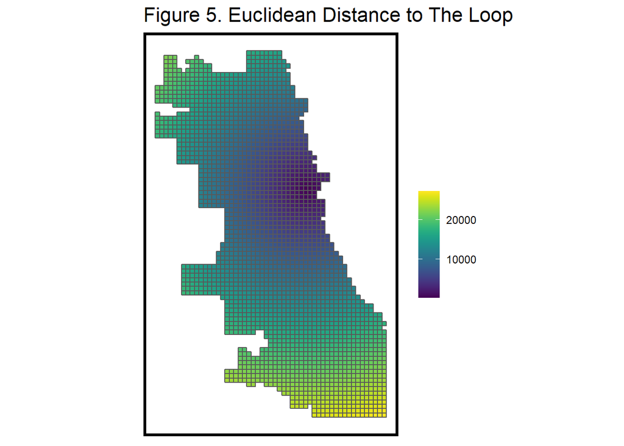

```r
loopPoint<-filter(neighborhoods,name=="Loop")%>%
  st_centroid()
vars_net$loopDistance=st_distance(st_centroid(vars_net),loopPoint)%>%
  as.numeric()

ggplot() +
  geom_sf(data=vars_net, aes(fill=loopDistance)) +
  scale_fill_viridis(name="") +
  labs(title="Figure 5. Euclidean Distance to The Loop") +
  mapTheme()
```

Next, the police districts is joined with neighbourhood using grid cell centroids.

```r
#create final_set
final_net<-left_join(crime_net,st_drop_geometry(vars_net),by="uniqueID")
final_net<-st_centroid(final_net)%>%
  st_join(dplyr::select(neighborhoods,name))%>%
  st_join(dplyr::select(policeDistricts,District))%>%
  st_drop_geometry()%>%
  left_join(dplyr::select(final_net,geometry,uniqueID))%>%
  st_sf()%>%
  na.omit()
```

## Local Moran’s I

To account for the neighborhood scale clustering at more local scale, Local Moran’s I is calculated to test that whether drug crime count at a given location distributed randomly relative to its immediate neighbors. Figure 6 shows the local spatial process of drug crime. High value of local moran’s I, together with low P-value (p<0.05) and significant hotspots concentrated almost same as the clustering area detected in figure 1 previously. The higher value of local moran’s I is, the lower P-value is, the stronger spatial autocorrelaton is and the more risky the crime hotspot is. We assume that a fit model should predict both hotspots and coldspots well.

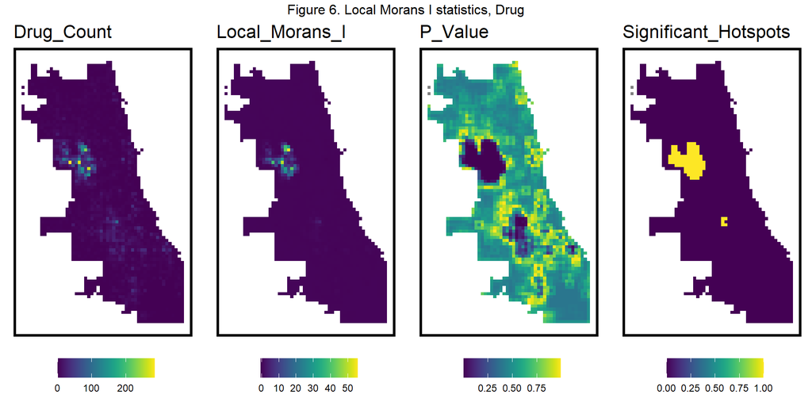

```r
final_net.nb <- poly2nb(as_Spatial(final_net), queen=TRUE)
final_net.weights <- nb2listw(final_net.nb, style="W", zero.policy=TRUE)

## see local moran
local_morans <- localmoran(final_net$countDrug, final_net.weights, zero.policy=TRUE) %>%
  as.data.frame()

# join local Moran's I results to fishnet
final_net.localMorans <-
  cbind(local_morans, as.data.frame(final_net)) %>%
  st_sf() %>%
  dplyr::select(Drug_Count = countDrug,
                Local_Morans_I = Ii,
                P_Value = `Pr(z != E(Ii))`) %>%
  mutate(Significant_Hotspots = ifelse(P_Value <= 0.001, 1, 0)) %>%
  gather(Variable, Value, -geometry)

vars<-unique(final_net.localMorans$Variable)
varList<-list()
for(i in vars){
  varList[[i]]<-
    ggplot()+
    geom_sf(data=filter(final_net.localMorans,Variable==i),
            aes(fill=Value),colour=NA)+
    scale_fill_viridis(name="")+
    labs(title=i)+
    mapTheme()+
    theme(legend.position="bottom")}
do.call(grid.arrange,c(varList,ncol=4,top="Figure 6. Local Morans I statistics, Drug"))
```

To measure the distance to those significant drug hotspots, drug.isSig is created, which denotes that whether a cell is significant cluster, while drug.isSig.dist then measured the distance between each cell centroid to its nearest significant cluster. The results were shown as figure 7.

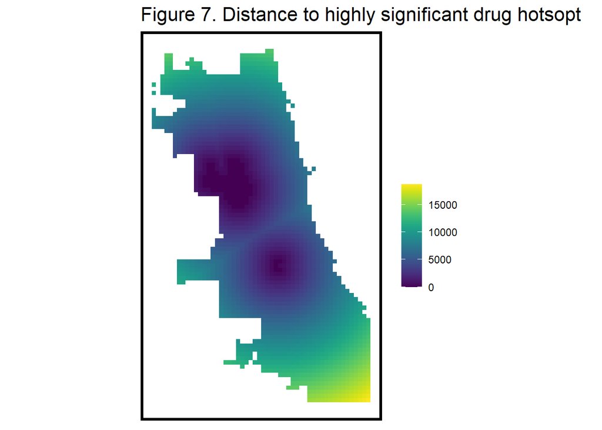

```r
final_net <- final_net %>%
  mutate(drug.isSig =
           ifelse(local_morans[,5] <= 0.001, 1, 0)) %>%
  mutate(drug.isSig.dist =
           nn_function(st_c(st_coid(final_net)),
                       st_c(st_coid(filter(final_net,
                                           drug.isSig == 1))),
                       k = 1))

ggplot()+
  geom_sf(data=final_net, aes(fill = drug.isSig.dist), colour=NA) +
  scale_fill_viridis(name="")+
  labs(title="Figure 7. Distance to highly significant drug hotsopt")+
  mapTheme()
```

## Correlation test

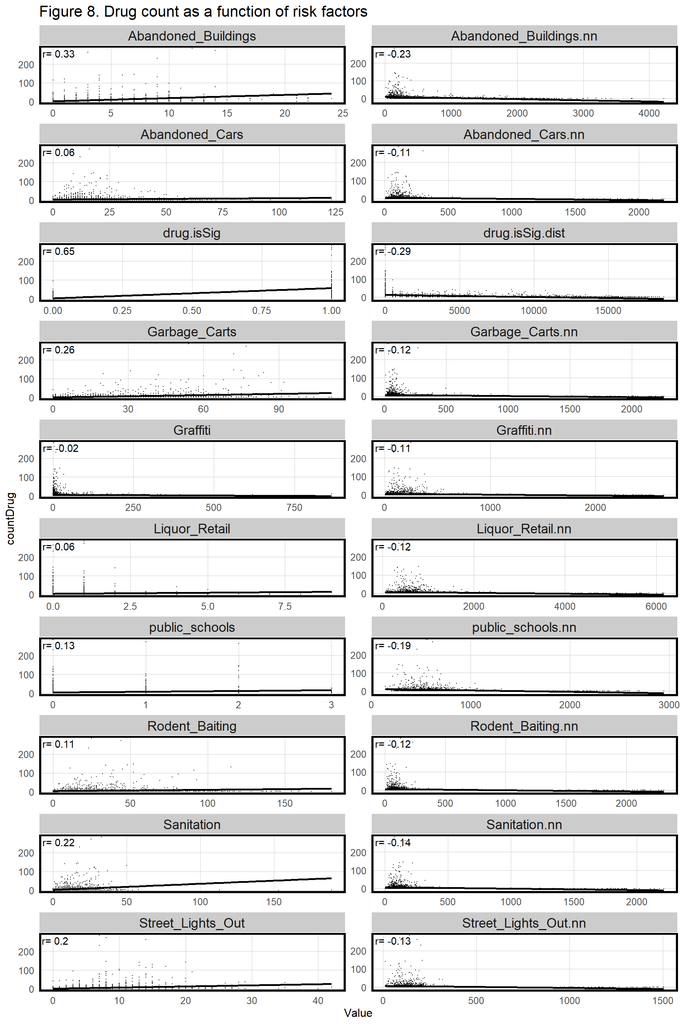

```r
correlation.long<-st_drop_geometry(final_net)%>%
  dplyr::select(-uniqueID,-cvID,-loopDistance,-name,-District)%>%
  gather(Variable,Value,-countDrug)

correlation.cor<-correlation.long%>%
  group_by(Variable)%>%
  summarize(correlation=cor(Value,countDrug,use="complete.obs"))

ggplot(correlation.long,aes(Value,countDrug))+
  geom_point(size=0.1)+
  geom_text(data=correlation.cor,
            aes(label=paste("r=",round(correlation,2))),
            x=-Inf,y=Inf,vjust=1.5,hjust=-.1)+
  geom_smooth(method="lm",se=FALSE,colour="black")+
  facet_wrap(~Variable,ncol=2,scales="free")+
  labs(title="Figure 8. Drug count as a function of risk factors")+
  plotTheme()
```

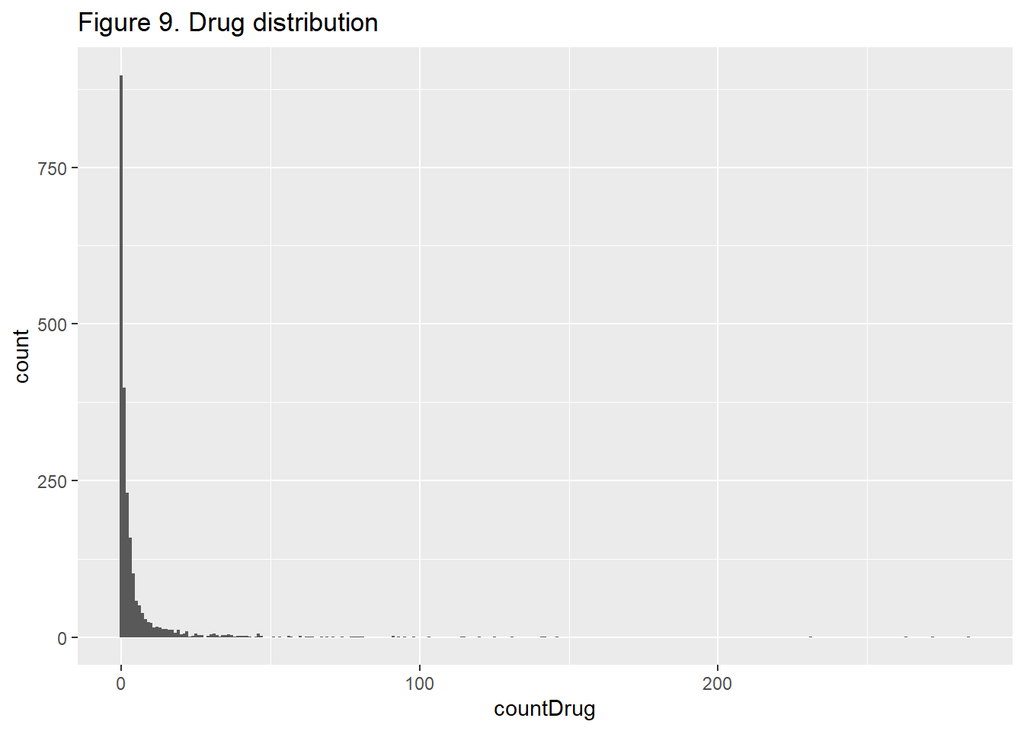

```r
#A histogram of your dependent variable.
ggplot(final_net, aes(countDrug)) +
  geom_histogram(binwidth = 1) +
  labs(title = "Figure 9. Drug distribution")
```

## Cross-validated Poisson Regression

We finally selected all the nearest neighbor features of each risk factors and loop distance as predictors to build the Poisson regression model. To validate the results predicted by the Poisson regression model two types of cross validation is conducted:  
(1) K-fold cross validation, where each time we take one segment as a testing set, while the rest of k-1 segments are the training dataset. reg.cv and reg.ss.cv perform random k-fold cross validation.  
(2) LOGO-CV(spatial cross-validation on neighborhood), where each time we tested a neighbourhood data, while the rest are training dataset. reg.spatialCV and reg.ss.spatialCV perform LOGO-CV.

```r
crossValidate <- function(dataset, id, dependentVariable, indVariables) {

  allPredictions <- data.frame()
  cvID_list <- unique(dataset[[id]])

  for (i in cvID_list) {

    thisFold <- i
    cat("This hold out fold is", thisFold, "\n")

    fold.train <- filter(dataset, dataset[[id]] != thisFold) %>% as.data.frame() %>%
      dplyr::select(id, geometry, indVariables, dependentVariable)
    fold.test  <- filter(dataset, dataset[[id]] == thisFold) %>% as.data.frame() %>%
      dplyr::select(id, geometry, indVariables, dependentVariable)

    regression <-
      glm(countDrug ~ ., family = "poisson",
          data = fold.train %>%
            dplyr::select(-geometry, -id))

    thisPrediction <-
      mutate(fold.test, Prediction = predict(regression, fold.test, type = "response"))

    allPredictions <-
      rbind(allPredictions, thisPrediction)

  }
  return(st_sf(allPredictions))
}

reg.vars <- c("Abandoned_Buildings.nn", "Abandoned_Cars.nn", "Graffiti.nn",
              "Liquor_Retail.nn", "Street_Lights_Out.nn", "Sanitation.nn", "Garbage_Carts.nn","public_schools.nn","Rodent_Baiting.nn",
              "loopDistance")

reg.ss.vars <- c("Abandoned_Buildings.nn", "Abandoned_Cars.nn", "Graffiti.nn",
                 "Liquor_Retail.nn", "Street_Lights_Out.nn", "Sanitation.nn", "Garbage_Carts.nn","public_schools.nn","Rodent_Baiting.nn",
                 "loopDistance", "drug.isSig", "drug.isSig.dist")

reg.cv <- crossValidate(
  dataset = final_net,
  id = "cvID",
  dependentVariable = "countDrug",
  indVariables = reg.vars) %>%
  dplyr::select(cvID = cvID, countDrug, Prediction, geometry)

reg.ss.cv <- crossValidate(
  dataset = final_net,
  id = "cvID",
  dependentVariable = "countDrug",
  indVariables = reg.ss.vars) %>%
  dplyr::select(cvID = cvID, countDrug, Prediction, geometry)

## RUN REGRESSIONS
reg.ss.spatialCV <- crossValidate(
  dataset = final_net,
  id = "name",
  dependentVariable = "countDrug",
  indVariables = reg.ss.vars) %>%
  dplyr::select(cvID = name, countDrug, Prediction, geometry)

reg.spatialCV <- crossValidate(
  dataset = final_net,
  id = "name",
  dependentVariable = "countDrug",
  indVariables = reg.vars) %>%
  dplyr::select(cvID = name, countDrug, Prediction, geometry)
```

## Accuracy & Generalzability

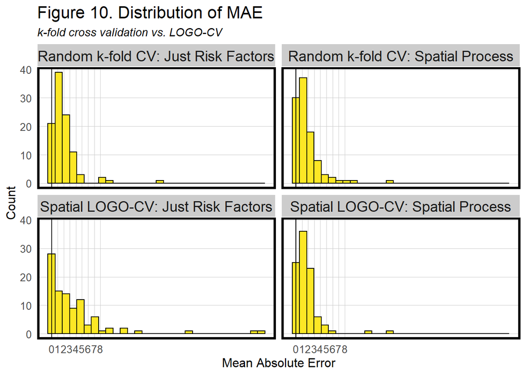

```r
reg.summary <-
  rbind(
    mutate(reg.cv,           Error = Prediction - countDrug,
           Regression = "Random k-fold CV: Just Risk Factors"),

    mutate(reg.ss.cv,        Error = Prediction - countDrug,
           Regression = "Random k-fold CV: Spatial Process"),

    mutate(reg.spatialCV,    Error = Prediction - countDrug,
           Regression = "Spatial LOGO-CV: Just Risk Factors"),

    mutate(reg.ss.spatialCV, Error = Prediction - countDrug,
           Regression = "Spatial LOGO-CV: Spatial Process")) %>%
  st_sf()

error_by_reg_and_fold <-
  reg.summary %>%
  group_by(Regression, cvID) %>%
  summarize(Mean_Error = mean(Prediction - countDrug, na.rm = T),
            MAE = mean(abs(Mean_Error), na.rm = T),
            SD_MAE = mean(abs(Mean_Error), na.rm = T)) %>%
  ungroup()

error_by_reg_and_fold %>%
  ggplot(aes(MAE)) +
  geom_histogram(bins = 30, colour="black", fill = "#FDE725FF") +
  facet_wrap(~Regression) +
  geom_vline(xintercept = 0) + scale_x_continuous(breaks = seq(0, 8, by = 1)) +
  labs(title="Figure 10. Distribution of MAE", subtitle = "k-fold cross validation vs. LOGO-CV",
       x="Mean Absolute Error", y="Count") +
  plotTheme()
```

```r
# A table of MAE and standard deviation MAE by regression
st_drop_geometry(error_by_reg_and_fold) %>%
  group_by(Regression) %>%
  summarize(Mean_MAE = round(mean(MAE), 2),
            SD_MAE = round(sd(MAE), 2)) %>%
  kable(caption = "Table 1. MAE and standard deviation MAE by regression") %>%
  kable_styling("striped", full_width = F) %>%
  row_spec(2, color = "black", background = "#FDE725FF") %>%
  row_spec(4, color = "black", background = "#FDE725FF")
```

Table 1. MAE and standard deviation MAE by regression

| Regression | Mean_MAE | SD_MAE |
| --- | --- | --- |
| Random k-fold CV: Just Risk Factors | 2.04 | 2.26 |
| Random k-fold CV: Spatial Process | 1.83 | 2.25 |
| Spatial LOGO-CV: Just Risk Factors | 3.71 | 5.66 |
| Spatial LOGO-CV: Spatial Process | 1.80 | 2.15 |

The spatial errors both k-fold and LOGO-CV were visualized in figure 11, where yellow areas mean higher errors. For both validation methods, the spatial errors decreased after adding spatial process elements, especially for errors around drug crime hotspots in LOGO-CV cross validation. The largest errors are located in the hotspot locations, though not obviously shown in K-fold validation. We hence believe that LOGO-CV cross validation provides more helpful information for our later analysis of this model.

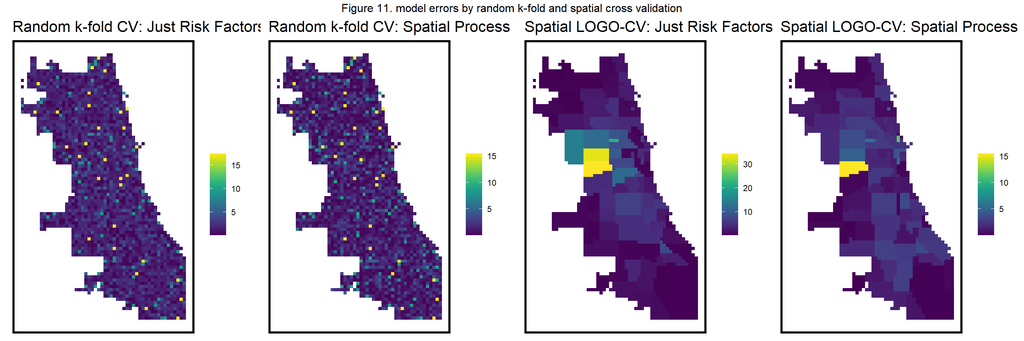

```r
#map of model errors by random k-fold and spatial cross validation
map_name<-unique(error_by_reg_and_fold$Regression)
map_list<-list()

for(i in map_name){
  map_list[[i]] <-
    ggplot() +
    geom_sf(data = filter(error_by_reg_and_fold, Regression == i),
            aes(fill=MAE), colour=NA) +
    scale_fill_viridis(name="") +
    labs(title=i) +
    mapTheme()}

do.call(grid.arrange,c(map_list, ncol=4, top="Figure 11. model errors by random k-fold and spatial cross validation"))
```

## Generalizability by race context

```r
#A table of raw errors by race context for a random k-fold vs. spatial cross validation regression.
tracts17 <-
  get_acs(geography = "tract", variables = c("B01001_001E","B01001A_001E"),
          year = 2017, state=17, county=031, geometry=T) %>%
  st_transform('ESRI:102271')  %>%
  dplyr::select(variable, estimate, GEOID) %>%
  spread(variable, estimate) %>%
  rename(TotalPop = B01001_001,
         NumberWhites = B01001A_001) %>%
  mutate(percentWhite = NumberWhites / TotalPop,
         raceContext = ifelse(percentWhite > .5, "Majority_White", "Majority_Non_White")) %>%
  .[neighborhoods,]
```

```r
reg.summary %>%
  filter(str_detect(Regression, "LOGO")) %>%
  st_centroid() %>%
  st_join(tracts17) %>%
  na.omit() %>%
  st_drop_geometry() %>%
  group_by(Regression, raceContext) %>%
  summarize(mean.Error = mean(Error, na.rm = T)) %>%
  spread(raceContext, mean.Error) %>%
  kable(caption = "Table 2. Mean Error by neighborhood racial context") %>%
  kable_styling("striped", full_width = F)
```

Table 2. Mean Error by neighborhood racial context

| Regression | Majority_Non_White | Majority_White |
| --- | --- | --- |
| Spatial LOGO-CV: Just Risk Factors | -1.6767844 | 1.7375603 |
| Spatial LOGO-CV: Spatial Process | -0.6228354 | 0.6175292 |

## Density vs. prediction

The risk prediction model, which captures crime in 2018, is compared with the 2017 kernel density to see which model perform better in crime prediction, and this was shown in figure 12. The black points represent the exact drug crime in 2018. By comparing the extent how the distribution of these points aligns with the risk category, we can decide which model is better. Looking at the crime hotspots, risk prediction model shows that high risk category is more precisely related to high density of crime points, while the kernel density model shows less alignment between the crime points and its relevant risk categories. We hence believe that risk prediction is a more suitable model.

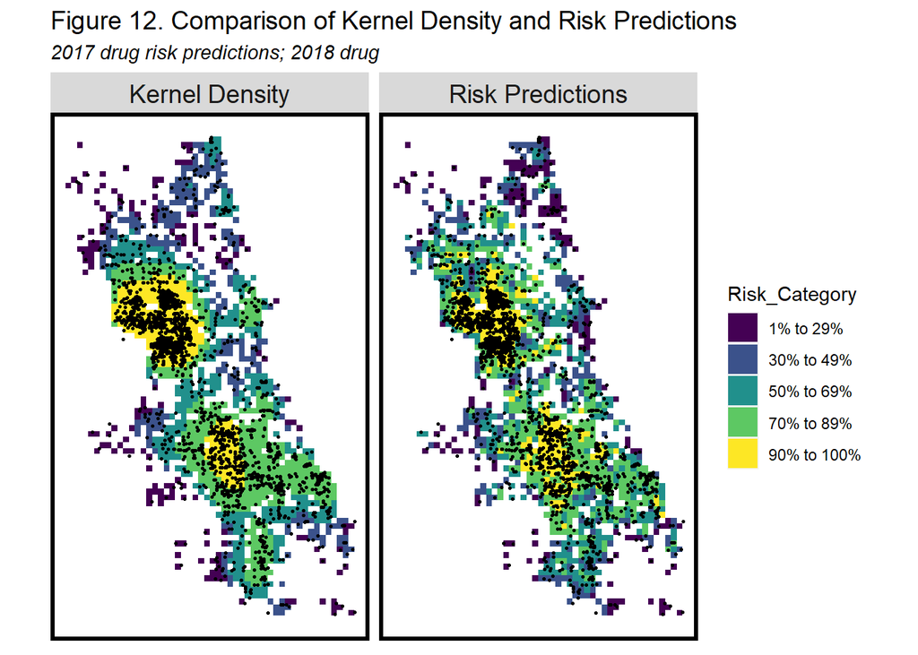

```r
#The map comparing kernel density to risk predictions for the next year’s crime.
#downloads drug18
drug18 <-
  read.socrata("https://data.cityofchicago.org/Public-Safety/Crimes-2018/3i3m-jwuy") %>%
  filter(Primary.Type == "NARCOTICS") %>%
  mutate(x = gsub("[()]", "", Location)) %>%
  separate(x,into= c("Y","X"), sep=",") %>%
  mutate(X = as.numeric(X),Y = as.numeric(Y)) %>%
  #na.omit() %>%
  filter(is.na(X)==FALSE) %>%
  st_as_sf(coords = c("X", "Y"), crs = 4326, agr = "constant")%>%
  st_transform('ESRI:102271') %>%
  distinct()%>%
  .[fishnet,]

drug_ppp <- as.ppp(st_coordinates(drug), W = st_bbox(final_net))
drug_KD.1000 <- spatstat.core::density.ppp(drug_ppp, 1000)

drug_KDE_sf <- as.data.frame(drug_KD.1000) %>%
  st_as_sf(coords = c("x", "y"), crs = st_crs(final_net)) %>%
  aggregate(., final_net, mean) %>%
  mutate(label = "Kernel Density",
         Risk_Category = ntile(value, 100),
         Risk_Category = case_when(
           Risk_Category >= 90 ~ "90% to 100%",
           Risk_Category >= 70 & Risk_Category <= 89 ~ "70% to 89%",
           Risk_Category >= 50 & Risk_Category <= 69 ~ "50% to 69%",
           Risk_Category >= 30 & Risk_Category <= 49 ~ "30% to 49%",
           Risk_Category >= 1 & Risk_Category  <= 29 ~ "1% to 29%")) %>%
  cbind(
    aggregate(
      dplyr::select(drug18) %>% mutate(drugCount = 1), ., sum) %>%
      mutate(burgCount = replace_na(drugCount, 0))) %>%
  dplyr::select(label, Risk_Category, drugCount)

drug_risk_sf <-
  reg.ss.spatialCV %>%
  mutate(label = "Risk Predictions",
         Risk_Category = ntile(Prediction, 100),
         Risk_Category = case_when(
           Risk_Category >= 90 ~ "90% to 100%",
           Risk_Category >= 70 & Risk_Category <= 89 ~ "70% to 89%",
           Risk_Category >= 50 & Risk_Category <= 69 ~ "50% to 69%",
           Risk_Category >= 30 & Risk_Category <= 49 ~ "30% to 49%",
           Risk_Category >= 1 & Risk_Category <= 29 ~ "1% to 29%")) %>%
  cbind(
    aggregate(
      dplyr::select(drug18) %>% mutate(drugCount = 1), ., sum) %>%
      mutate(burgCount = replace_na(drugCount, 0))) %>%
  dplyr::select(label,Risk_Category, drugCount)

rbind(drug_KDE_sf, drug_risk_sf) %>%
  na.omit() %>%
  gather(Variable, Value, -label, -Risk_Category, -geometry) %>%
  ggplot() +
  geom_sf(aes(fill = Risk_Category), colour = NA) +
  geom_sf(data = sample_n(drug18, 3000), size = .5, colour = "black") +
  facet_wrap(~label, ) +
  scale_fill_viridis(discrete = TRUE) +
  labs(title="Figure 12. Comparison of Kernel Density and Risk Predictions",
       subtitle="2017 drug risk predictions; 2018 drug") +
  mapTheme(title_size = 14)
```

However, the visual judgement from the maps may not always be accurate. So we also make the bar plots as figure 13 shows, which compare the kernel density and risk prediction side by side. For risk categories that ranges is (1%,29%), (30%,49%) and (90%,100%), the rate of drug crime between kernel density and risk prediction is close. In range (50%-69%), the drug crime rate estimated by the risk prediction was a little higher than the kernel density, but kernel density modelled more crime rate than the risk prediction in range (70%-89%). It is hard to tell which model is more accurate in predicting the drug crime in Chicago.

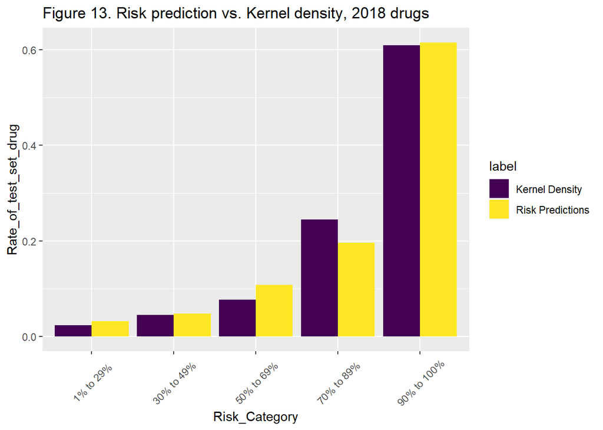

```r
#The bar plot making this comparison.
rbind(drug_KDE_sf, drug_risk_sf) %>%
  st_set_geometry(NULL) %>% na.omit() %>%
  gather(Variable, Value, -label, -Risk_Category) %>%
  group_by(label, Risk_Category) %>%
  summarize(countDrug = sum(Value)) %>%
  ungroup() %>%
  group_by(label) %>%
  mutate(Rate_of_test_set_drug = countDrug / sum(countDrug)) %>%
  ggplot(aes(Risk_Category,Rate_of_test_set_drug)) +
  geom_bar(aes(fill=label), position="dodge", stat="identity") +
  scale_fill_viridis(discrete = TRUE) +
  labs(title = "Figure 13. Risk prediction vs. Kernel density, 2018 drugs") +
  theme(axis.text.x = element_text(angle = 45, vjust = 0.5))
```

## Conclusion

By introducing some feature engineering elements, analyzing the local spatial process and conducting spatial cross-validation, this study established a geospatial risk prediction model to predict the drug crime in Chicago, but this model is not recommended for the police for several reasons. First, despite the spatial process elements help decrease the MAE of the model, the MAE is still greater than 100%, while a model with MAE smaller than 20% is believed to be ideal. In addition, even this model can reduce spatial errors across neighbourhood racial context, it still causes over-prediction for white group and underestimation for non-white group, which will bring misinformation to the police. Furthermore, although it is observed geographically that the reality crime data aligns more with the risk category predicted by prediction model than the kernel density, when we quantify the risk category in bar plots, the accuracy of risk prediction does not surpass the kernel density.  
To build a better risk prediction model, the selection and processing process of predictors is important. In our study, the nearest neighbor of our features has lower correlation than the feature counts. To improve the prediction model, more potential environmental, demographical and socioeconomic factors should be considered. Ideally, for nn_function, different k of scale definitions should also be tested.

References:  
Moore,M.H.,& Kleiman,M.(1989). The police and Drugs. U.S. Dept. of Justice, Office of Justice Programs, National Institute of Justice.  
Steif, Ken. n.d. Public Policy Analytics.